# filter_by_variant_effect_wecare_only_jan2017_explore

started: Alexey Larionov, 2016  
last updated: Alexey Larionov, 24Feb2017

# Summary

### Exploring removal of common variants (AF>5-10%)

### on genes with multiple protein-affecting variants

Modest effect. Slightly playes down MUC4 etc.

### Exploring BRCA1, BRCA2, PALB2 carriers

Still there is a number of BRCA1, BRCA2, PALB2 carriers.  
All detected variants were reviewed in Dec 2016 and found non-pathogenic.

# start_section

```r
# Start time
Sys.time()
```

```
## [1] "2017-03-06 11:34:12 GMT"
```

```r
# Folders
setwd("/scratch/medgen/scripts/wecare_stat_01.17/scripts")
interim_data_folder <- "/scratch/medgen/scripts/wecare_stat_01.17/interim_data"

# Load libraries
library(dplyr)
```

# load_data

```r
# Load data
load(paste(interim_data_folder, "s07a_filter_by_variant_effect_wecare_only_jan2017.RData", sep="/"))
```

# check_data

```r
ls()
```

```
## [1] "interim_data_folder"  "results_folder"       "summary_counts.df"
## [4] "wecare_exac.df"       "wecare_genotypes.mx"  "wecare_kgen.df"
## [7] "wecare_phenotypes.df" "wecare_variants.df"
```

```r
dim(wecare_genotypes.mx)
```

```
## [1] 17598   474
```

```r
class(wecare_genotypes.mx)
```

```
## [1] "matrix"
```

```r
wecare_genotypes.mx[1:5,1:5]
```

```
##              P1_A01 P1_A02 P1_A03 P1_A04 P1_A05
## Var000000026      0     NA      0      0      0
## Var000000029      0      0      0      0      0
## Var000000031      0      0      0      0      0
## Var000000053      0      0      0      0     NA
## Var000000064      0      0      0      0     NA
```

```r
dim(wecare_phenotypes.df)
```

```
## [1] 474  32
```

```r
str(wecare_phenotypes.df)
```

```
## 'data.frame':    474 obs. of  32 variables:
##  $ wes_id        : chr  "P1_A01" "P1_A02" "P1_A03" "P1_A04" ...
##  $ gwas_id       : chr  "id203568" "id357807" "id325472" "id304354" ...
##  $ merged_id     : chr  "P1_A01_id203568" "P1_A02_id357807" "P1_A03_id325472" "P1_A04_id304354" ...
##  $ filter        : chr  "pass" "pass" "pass" "pass" ...
##  $ cc            : num  1 1 1 1 1 1 0 1 1 0 ...
##  $ setno         : int  203568 357807 325472 304354 222648 244843 276284 297810 250898 226974 ...
##  $ registry      : chr  "IR" "LA" "IA" "IA" ...
##  $ family_history: int  1 0 1 1 1 1 1 1 1 0 ...
##  $ age_dx        : int  49 35 32 33 44 28 28 38 35 36 ...
##  $ age_ref       : num  58 36 41 34 49 28 32 44 35 38 ...
##  $ rstime        : num  10.17 1.83 9.75 1.59 5.66 ...
##  $ eig1_gwas     : num  -0.00389 -0.00379 -0.01011 -0.01288 -0.01086 ...
##  $ eig2_gwas     : num  0.00266 0.00246 -0.0001 0.00595 0.01157 ...
##  $ eig3_gwas     : num  0.06803 0.05055 -0.00603 0.00747 0.00144 ...
```

[output cut: 18 more lines]

```r
wecare_phenotypes.df[1:5,1:5]
```

```
##        wes_id  gwas_id       merged_id filter cc
## P1_A01 P1_A01 id203568 P1_A01_id203568   pass  1
## P1_A02 P1_A02 id357807 P1_A02_id357807   pass  1
## P1_A03 P1_A03 id325472 P1_A03_id325472   pass  1
## P1_A04 P1_A04 id304354 P1_A04_id304354   pass  1
## P1_A05 P1_A05 id222648 P1_A05_id222648   pass  1
```

```r
dim(wecare_variants.df)
```

```
## [1] 17598    44
```

```r
colnames(wecare_variants.df)
```

```
##  [1] "SplitVarID"         "SYMBOL"             "TYPE"
##  [4] "CHROM"              "POS"                "REF"
##  [7] "ALT"                "AC"                 "AF"
## [10] "AN"                 "Consequence"        "SIFT_call"
## [13] "SIFT_score"         "PolyPhen_call"      "PolyPhen_score"
## [16] "CLIN_SIG"           "cDNA_position"      "CDS_position"
## [19] "Codons"             "Protein_position"   "Amino_acids"
## [22] "Existing_variation" "Multiallelic"       "ac_wecare_cln"
## [25] "an_wecare_cln"      "af_wecare_cln"      "ac_ubc_cln"
## [28] "an_ubc_cln"         "af_ubc_cln"         "ac_cbc_cln"
## [31] "an_cbc_cln"         "af_cbc_cln"         "ac_ubc_fam_cln"
## [34] "an_ubc_fam_cln"     "af_ubc_fam_cln"     "ac_ubc_nofam_cln"
## [37] "an_ubc_nofam_cln"   "af_ubc_nofam_cln"   "ac_cbc_fam_cln"
## [40] "an_cbc_fam_cln"     "af_cbc_fam_cln"     "ac_cbc_nofam_cln"
## [43] "an_cbc_nofam_cln"   "af_cbc_nofam_cln"
```

```r
wecare_variants.df[1:5,1:5]
```

```
##                SplitVarID SYMBOL TYPE CHROM    POS
## Var000000026 Var000000026  NOC2L  SNP     1 881871
## Var000000029 Var000000029  NOC2L  SNP     1 883883
## Var000000031 Var000000031  NOC2L  SNP     1 883946
## Var000000053 Var000000053 KLHL17  SNP     1 897287
## Var000000064 Var000000064 KLHL17  SNP     1 897792
```

```r
dim(wecare_kgen.df)
```

```
## [1] 17598     9
```

```r
colnames(wecare_kgen.df)
```

```
## [1] "SplitVarID"  "kgen.AC"     "kgen.AN"     "kgen.AF"     "kgen.AFR_AF"
## [6] "kgen.AMR_AF" "kgen.EAS_AF" "kgen.EUR_AF" "kgen.SAS_AF"
```

```r
wecare_kgen.df[1:5,1:5]
```

```
##                SplitVarID kgen.AC kgen.AN     kgen.AF kgen.AFR_AF
## Var000000026 Var000000026      NA      NA          NA          NA
## Var000000029 Var000000029       1    5008 0.000199681           0
## Var000000031 Var000000031       1    5008 0.000199681           0
## Var000000053 Var000000053      NA      NA          NA          NA
## Var000000064 Var000000064      NA      NA          NA          NA
```

```r
dim(wecare_exac.df)
```

```
## [1] 17598    48
```

```r
colnames(wecare_exac.df)
```

```
##  [1] "SplitVarID"              "exac_non_TCGA.AF"
##  [3] "exac_non_TCGA.AC"        "exac_non_TCGA.AN"
##  [5] "exac_non_TCGA.AC_FEMALE" "exac_non_TCGA.AN_FEMALE"
##  [7] "exac_non_TCGA.AC_MALE"   "exac_non_TCGA.AN_MALE"
##  [9] "exac_non_TCGA.AC_Adj"    "exac_non_TCGA.AN_Adj"
## [11] "exac_non_TCGA.AC_Hom"    "exac_non_TCGA.AC_Het"
## [13] "exac_non_TCGA.AC_Hemi"   "exac_non_TCGA.AC_AFR"
## [15] "exac_non_TCGA.AN_AFR"    "exac_non_TCGA.Hom_AFR"
## [17] "exac_non_TCGA.Het_AFR"   "exac_non_TCGA.Hemi_AFR"
## [19] "exac_non_TCGA.AC_AMR"    "exac_non_TCGA.AN_AMR"
## [21] "exac_non_TCGA.Hom_AMR"   "exac_non_TCGA.Het_AMR"
## [23] "exac_non_TCGA.Hemi_AMR"  "exac_non_TCGA.AC_EAS"
## [25] "exac_non_TCGA.AN_EAS"    "exac_non_TCGA.Hom_EAS"
## [27] "exac_non_TCGA.Het_EAS"   "exac_non_TCGA.Hemi_EAS"
## [29] "exac_non_TCGA.AC_FIN"    "exac_non_TCGA.AN_FIN"
## [31] "exac_non_TCGA.Hom_FIN"   "exac_non_TCGA.Het_FIN"
## [33] "exac_non_TCGA.Hemi_FIN"  "exac_non_TCGA.AC_NFE"
## [35] "exac_non_TCGA.AN_NFE"    "exac_non_TCGA.Hom_NFE"
## [37] "exac_non_TCGA.Het_NFE"   "exac_non_TCGA.Hemi_NFE"
## [39] "exac_non_TCGA.AC_SAS"    "exac_non_TCGA.AN_SAS"
## [41] "exac_non_TCGA.Hom_SAS"   "exac_non_TCGA.Het_SAS"
## [43] "exac_non_TCGA.Hemi_SAS"  "exac_non_TCGA.AC_OTH"
## [45] "exac_non_TCGA.AN_OTH"    "exac_non_TCGA.Hom_OTH"
## [47] "exac_non_TCGA.Het_OTH"   "exac_non_TCGA.Hemi_OTH"
```

```r
wecare_exac.df[1:5,1:5]
```

```
##                SplitVarID exac_non_TCGA.AF exac_non_TCGA.AC
## Var000000026 Var000000026               NA               NA
## Var000000029 Var000000029        1.506e-04               16
## Var000000031 Var000000031        2.354e-04               25
## Var000000053 Var000000053        1.883e-05                2
## Var000000064 Var000000064        9.416e-06                1
##              exac_non_TCGA.AN exac_non_TCGA.AC_FEMALE
## Var000000026               NA                      NA
## Var000000029           106210                       8
## Var000000031           106210                       4
## Var000000053           106210                       0
## Var000000064           106206                       0
```

```r
# Check consistency of rownames and colnames
sum(colnames(wecare_genotypes.mx) != rownames(wecare_phenotypes.df))
```

```
## [1] 0
```

```r
sum(rownames(wecare_genotypes.mx) != rownames(wecare_variants.df))
```

```
## [1] 0
```

```r
sum(rownames(wecare_genotypes.mx) != rownames(wecare_kgen.df))
```

```
## [1] 0
```

```r
sum(rownames(wecare_genotypes.mx) != rownames(wecare_exac.df))
```

```
## [1] 0
```

# explore_non_common_variants

Defining variants that are not common as the following:  
[ kgen EUR AF < 5% or NA ] AND [ wecare AF < 10 ]

Weighting by AF in the downstream analysis should take care of the remaining ~5% of proteing-affecting variants that happened to be common.

Genes with diverse non-common protein-affecting variants still include: ATM (14 types of variants), POLG (12), POLQ(11), BRCA2 (10) Other potentially interesting genes with many different types of protein-affecting variant include: FN1 (10), MKI67 (8), CHEK2 (7), MLH3 (7),

```r
# Non-common  kgen
non_common_kgen_variants <- wecare_kgen.df$kgen.EUR_AF < 0.05
summary(non_common_kgen_variants)
```

```
##    Mode   FALSE    TRUE    NA's
## logical    1032    6533   10033
```

```r
TRUE -> non_common_kgen_variants[is.na(non_common_kgen_variants)]
summary(non_common_kgen_variants) # 16,601
```

```
##    Mode   FALSE    TRUE    NA's
## logical    1032   16566       0
```

```r
# Non-common wecare
non_common_wecare_variants <- wecare_variants.df$af_wecare_cln < 0.1
summary(non_common_wecare_variants) # 16,824
```

```
##    Mode   FALSE    TRUE    NA's
## logical     811   16787       0
```

```r
# Non-common combined
non_common_variants <- non_common_kgen_variants & non_common_wecare_variants
summary(non_common_variants) # 16,515
```

```
##    Mode   FALSE    TRUE    NA's
## logical    1118   16480       0
```

```r
# Get number of retained genes
length(unique(wecare_variants.df[non_common_variants,"SYMBOL"])) # 8,478
```

```
## [1] 8469
```

```r
# Variants per gene
x <- sort(table(as.vector(wecare_variants.df[non_common_variants,"SYMBOL"])), decreasing = TRUE)
x[1:300]
```

```
##
##    DNAH7    DNAH3   MT-CYB      ATM   COL6A6    DUOX2   MYO18B    C2CD3
##       23       21       18       14       14       14       14       13
##     CUBN   IGSF10  PDE4DIP    PKHD1  PKHD1L1    SPTA1    TRPM1    ABCC2
##       13       13       13       13       13       13       13       12
##    LAMA1     LRBA     MUC4   PKD1L2     POLG     SPTB    ABCA4    MYO1A
##       12       12       12       12       12       12       11       11
##    MYO7A     NID2     NOD2     PLB1     POLQ   PRUNE2    BRCA2   CCDC66
##       11       11       11       11       11       11       10       10
##    DCHS2    ECT2L   FER1L6      FN1    LAMA2      MPO    MYOM2     ANK1
##       10       10       10       10       10       10       10        9
##    ATP7B   GPR113   KCNJ12    KRT36    LAMB2    MYH13   SLC5A4    STAB2
##        9        9        9        9        9        9        9        9
##       TG      TNC     VWA8   ZNF106   ZNF568    A2ML1    ABCA3    ABCB5
##        9        9        9        9        9        8        8        8
##      ACE ADAMTSL1    AMPD1     ASPM       C9    CD109    CES5A  COL28A1
##        8        8        8        8        8        8        8        8
##    CSMD3   DNAH14   DNASE1      EPX KIAA1217    LAMC3    MKI67    MYH14
##        8        8        8        8        8        8        8        8
##     MYH4     MYOF    MYOM1     NAV2    NLRP5    PADI4   PCDH15     PCK2
##        8        8        8        8        8        8        8        8
##    POMT1   PTPN13     SETX       SI     TEP1     TPTE   UNC45B     UTRN
##        8        8        8        8        8        8        8        8
##      WRN      XDH   ZNF268    ABCA8   ABCC11 ADAMTS14    AGBL1    ALPK2
##        8        8        8        7        7        7        7        7
##     ANO2     ATIC      BLK   CAPN13  CCDC141     CCR5   CELSR2    CHEK2
##        7        7        7        7        7        7        7        7
##    CNTLN  COL15A1      CR2  CTTNBP2    DAAM2   DNAH12    DNHD1   DOPEY2
##        7        7        7        7        7        7        7        7
##   EGFLAM     ELP2    EPB41     EXO1       F5   FRMPD1    IFIH1   IQGAP2
##        7        7        7        7        7        7        7        7
## KIAA0556    KRT75    LAMB4      LPA    LRRK1    LRRK2     MLH3    MYH15
##        7        7        7        7        7        7        7        7
##    MYO5C    MYO7B    NCOA3    NRDE2     OCA2    OGDHL   PDCD11     PHKB
##        7        7        7        7        7        7        7        7
##   PLA2R1  RAPGEF3   SETBP1  SLC10A2    SOGA2    SSFA2  TBC1D17    TEX15
##        7        7        7        7        7        7        7        7
##     TMC8  TMPRSS7  TRAPPC9    TTLL6  TUBGCP6    UGGT2     ULK4    USP45
##        7        7        7        7        7        7        7        7
##    UTP20    WDR27     WDR3    WDR41     WFS1   ZNF528      A2M    ABCB6
```

[output cut: 22 more lines]

```
##        6        6        6        6        6        6        6        6
##   RASSF6    RBM19    REV3L    RPAP1   RSPH4A   SCN10A    SCN9A   SEC16B
##        6        6        6        6        6        6        6        6
##   SEMA4G  SLC12A1  SLC22A1  SLC22A3   SLC3A1   SPAG17    SPEF2    SYTL2
##        6        6        6        6        6        6        6        6
##     SZT2  TBC1D9B   TCEB3B    TDRD6 TIMELESS     TLN2 TMPRSS15 TNKS1BP1
##        6        6        6        6        6        6        6        6
##    TRPM4   UMODL1   VPS13A     VRK2   ZNF429   ZNF559   ZSWIM2   ABCA12
##        6        6        6        6        6        6        6        5
##    ABCA9    ABCC1    ABHD1    ACACB   ACAD11     ACO1    ACOXL ADAMTS12
##        5        5        5        5        5        5        5        5
##    AMER3     ANO7     AOC2     APLF ARHGAP32    ASB15    ATAD5   ATP10B
##        5        5        5        5        5        5        5        5
##   ATP10D  ATP13A5   ATP8B3   ATP8B4
##        5        5        5        5
```

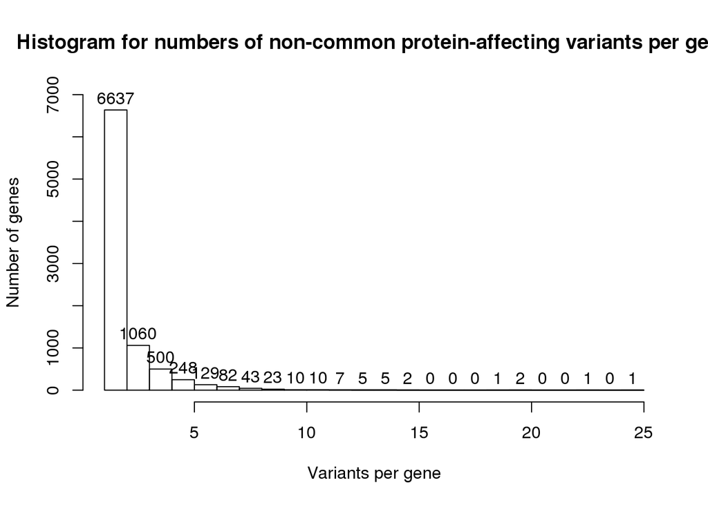

```r
# Save table of counts
y <- cbind(names(x),x)
c("gene","count") -> colnames(y)
write.table(y, file=paste(results_folder, "wecare_only_non_common_variants_per_gene.txt", sep="/"), quote = FALSE, row.names = FALSE)

# Plot histogram
z <- wecare_variants.df %>%  group_by(SYMBOL) %>% summarise(n())
"vars_count" -> colnames(z)[2]
hist(z$vars_count, main="Histogram for numbers of non-common protein-affecting variants per gene", xlab="Variants per gene", ylab="Number of genes", ylim=c(0,7000), breaks=25, labels = TRUE)
```

```r
mean(z$vars_count) # 2.008438
```

```
## [1] 2.007529
```

```r
# Clean-up
rm(non_common_kgen_variants, non_common_wecare_variants, non_common_variants, x,y,z)
```

# explore_BRCA1_carriers

4 different BRCA1 protein-affecting variants:  
all missenses (one pretty common: ~5%),  
all reviuved and considered non-pathogenic in Dec2016.

52 BRCA1 carriers (mainly carrying the common variant).

```r
# Select variants
brca1_variants <- wecare_variants.df$SYMBOL == "BRCA1"
summary(brca1_variants) # 4
```

```
##    Mode   FALSE    TRUE    NA's
## logical   17594       4       0
```

```r
# Select carriers
brca1_count_per_case <- apply(wecare_genotypes.mx[brca1_variants,], 2, sum, na.rm=TRUE)
summary(as.factor(brca1_count_per_case))
```

```
##   0   1   2
## 422  48   4
```

```r
brca1_carrier <- brca1_count_per_case > 0
summary(brca1_carrier) # 52
```

```
##    Mode   FALSE    TRUE    NA's
## logical     422      52       0
```

```r
# Subset dataset
wecare_brca1_genotypes.mx <- wecare_genotypes.mx[brca1_variants, brca1_carrier]
wecare_brca1_exac.df <- wecare_exac.df[brca1_variants,]
wecare_brca1_kgen.df <- wecare_kgen.df[brca1_variants,]
wecare_brca1_variants.df <- wecare_variants.df[brca1_variants,]
wecare_brca1_phenotypes.df <- wecare_phenotypes.df[brca1_carrier,]

# rs-ids: all have been revieved in Dec2016 and considered non-pathogenic.
wecare_brca1_variants.df[,c("SplitVarID","Existing_variation")]
```

```
##                SplitVarID Existing_variation
## Var000277619 Var000277619        rs397509146
## Var000277641 Var000277641         rs56012641
## Var000277645 Var000277645          rs1799950
## Var000277654 Var000277654         rs56187033
```

```r
# One case with compond heterozygous: P1_H07 carrying rs56012641 & rs56187033
brca1_homs <- apply(wecare_brca1_genotypes.mx, 2, sum, na.rm=TRUE) == 2
wecare_brca1_genotypes.mx[,brca1_homs]
```

```
##              P1_H07 P5_D02 P5_D05 P5_H04
## Var000277619      0      0      0      0
## Var000277641      1      0      0      0
## Var000277645      0      2      2      2
## Var000277654      1      0      0      0
```

```r
wecare_phenotypes.df["P1_H07",c("cc","age_dx","age_ref","rstime")]
```

```
##        cc age_dx age_ref rstime
## P1_H07  0     36      39   3.75
```

# explore_BRCA2_carriers

10 diferent BRCA2 protein-affecting variants:  
9 dd-misseswses and 1 relatively common stop-gain (~1%).  
All reviuved in Dec2016 and considered non-pathogenic.

30 BRCA2 carriers: most carrying the common stop-gain.

One compund heterozygous case carrying the common stop-gain and a rare dd missence:  
P3_C12 carrying rs11571747 & rs11571833 (UBC at 43 yrs)

```r
# Select variants
brca2_variants <- wecare_variants.df$SYMBOL == "BRCA2"
sum(brca2_variants) # 10
```

```
## [1] 10
```

```r
# Select carriers
brca2_count_per_case <- apply(wecare_genotypes.mx[brca2_variants,], 2, sum, na.rm=TRUE)
summary(as.factor(brca2_count_per_case))
```

```
##   0   1   2
## 444  29   1
```

```r
brca2_carrier <- brca2_count_per_case > 0
summary(brca2_carrier) # 30
```

```
##    Mode   FALSE    TRUE    NA's
## logical     444      30       0
```

```r
# Subset dataset
wecare_brca2_genotypes.mx <- wecare_genotypes.mx[brca2_variants, brca2_carrier]
wecare_brca2_exac.df <- wecare_exac.df[brca2_variants,]
wecare_brca2_kgen.df <- wecare_kgen.df[brca2_variants,]
wecare_brca2_variants.df <- wecare_variants.df[brca2_variants,]
wecare_brca2_phenotypes.df <- wecare_phenotypes.df[brca2_carrier,]

# rs-ids: all have been revieved in Dec2016 and considered non-pathogenic.
wecare_brca2_variants.df[,c("SplitVarID","Existing_variation")]
```

```
##                SplitVarID Existing_variation
## Var000223248 Var000223248         rs41293475
## Var000223283 Var000223283         rs28897728
## Var000223305 Var000223305         rs80358935
## Var000223313 Var000223313         rs80359014
## Var000223314 Var000223314        rs764248927
## Var000223318 Var000223318         rs28897745
## Var000223322 Var000223322         rs11571747
## Var000223325 Var000223325         rs28897754
## Var000223326 Var000223326         rs11571769
## Var000223332 Var000223332         rs11571833
```

```r
# One case with compond heterozygous: P3_C12 carrying rs11571747 & rs11571833
# the first of the variants is a rare dd missence, the second is a relatively common stop-gain (~1%)
brca2_homs <- apply(wecare_brca2_genotypes.mx, 2, sum, na.rm=TRUE) == 2
wecare_brca2_genotypes.mx[,brca2_homs]
```

```
## Var000223248 Var000223283 Var000223305 Var000223313 Var000223314
##            0            0            0            0            0
## Var000223318 Var000223322 Var000223325 Var000223326 Var000223332
##            0            1            0            0            1
```

```r
colnames(wecare_brca2_genotypes.mx)[brca2_homs]
```

```
## [1] "P3_C12"
```

```r
wecare_phenotypes.df["P3_C12",c("cc","age_dx","age_ref","rstime")]
```

```
##        cc age_dx age_ref rstime
## P3_C12  0     43      51    7.5
```

# explore_PALB2_carriers

5 diferent PALB2 protein-affecting variants: all dd-missenses, one - pretty common (~2.5% AF).  
All reviuved in Dec2016 and considered non-pathogenic.

34 PALB2 carriers, most carrying the common missense.

```r
# Select variants
palb2_variants <- wecare_variants.df$SYMBOL == "PALB2"
sum(palb2_variants) # 5
```

```
## [1] 5
```

```r
# Select carriers
palb2_count_per_case <- apply(wecare_genotypes.mx[palb2_variants,], 2, sum, na.rm=TRUE)
summary(as.factor(palb2_count_per_case)) # No homs or compond hets
```

```
##   0   1
## 440  34
```

```r
palb2_carrier <- palb2_count_per_case > 0
summary(palb2_carrier) # 34
```

```
##    Mode   FALSE    TRUE    NA's
## logical     440      34       0
```

```r
# Subset dataset
wecare_palb2_genotypes.mx <- wecare_genotypes.mx[palb2_variants, palb2_carrier]
wecare_palb2_exac.df <- wecare_exac.df[palb2_variants,]
wecare_palb2_kgen.df <- wecare_kgen.df[palb2_variants,]
wecare_palb2_variants.df <- wecare_variants.df[palb2_variants,]
wecare_palb2_phenotypes.df <- wecare_phenotypes.df[palb2_carrier,]

# rs-ids: all have been revieved in Dec2016 and considered non-pathogenic.
wecare_palb2_variants.df[,c("SplitVarID","Existing_variation")]
```

```
##                SplitVarID Existing_variation
## Var000258013 Var000258013         rs45551636
## Var000258016 Var000258016         rs45478192
## Var000258017 Var000258017         rs45624036
## Var000258019 Var000258019         rs45476495
## Var000258034 Var000258034         rs45510998
```

```r
# Cleanup
#rm(palb2_variants, palb2_count_per_case, palb2_carrier,
#   wecare_palb2_genotypes.mx, wecare_palb2_exac.df, wecare_palb2_kgen.df,
#   wecare_palb2_variants.df, wecare_palb2_phenotypes.df)
```

# brca1_brca2_combinations

3 cases simulteneously carrying BRCA1 and BRCA2 variants:

2 (P2_D05, P5_D08): carry het common (6%) dd-missense BRCA1 + het common (1%) stop-gain BRCA2 1 (P5_D05): carry hom common (0.36%=6%*6%) dd-missense BRCA1 + het rare (0.5%) dd-missense BRCA2

It seems that such number of combinations of non-pathogenic BRCA1-BRCA2 variants (at least for the 1st combination) would be possible to expect by chance. However, in each of 3 cases this “chance” coinsided with early onset (40-50 yrs) bilateral bc.

```r
brca1_brca2_carrier <- brca1_carrier & brca2_carrier
sum(brca1_brca2_carrier) # 3
```

```
## [1] 3
```

```r
brca1_brca2_carrier <- wecare_phenotypes.df[brca1_brca2_carrier,"wes_id"]
wecare_brca1_genotypes.mx[,brca1_brca2_carrier]
```

```
##              P2_D05 P5_D05 P5_D08
## Var000277619      0      0      0
## Var000277641      0      0      0
## Var000277645      1      2      1
## Var000277654      0      0      0
```

```r
wecare_brca2_genotypes.mx[,brca1_brca2_carrier]
```

```
##              P2_D05 P5_D05 P5_D08
## Var000223248      0      0      0
## Var000223283      0      0      0
## Var000223305      0      0      0
## Var000223313      0      0      0
## Var000223314      0      0      0
## Var000223318      0      0      0
## Var000223322      0      1      0
## Var000223325      0      0      0
## Var000223326      0      0      0
## Var000223332      1      0      1
```

```r
wecare_phenotypes.df[c("P2_D05", "P5_D08", "P5_D05"),c("cc","age_dx","age_ref","rstime")]
```

```
##        cc age_dx age_ref rstime
## P2_D05  1     40      50  10.25
## P5_D08  1     47      50   3.33
## P5_D05  1     44      47   2.75
```

# brca1_palb2_combinations

1 case (P4_C12) simulteneously carryes BRCA1 and PALB2 variants: het common (6%) dd-missense BRCA1 + het common (3%) dd-missense PALB2.

One such combination is likely to happen in 500 cases by chance (6%*3%/512). However, this chance coinsided with early onset (41 yrs) bilateral (41 + 45 yrs) bc phenotype.

```r
brca1_palb2_carrier <- brca1_carrier & palb2_carrier
sum(brca1_palb2_carrier) # 1
```

```
## [1] 1
```

```r
brca1_palb2_carrier <- wecare_phenotypes.df[brca1_palb2_carrier,"wes_id"]
brca1_palb2_carrier
```

```
## [1] "P4_C12"
```

```r
wecare_brca1_genotypes.mx[,brca1_palb2_carrier]
```

```
## Var000277619 Var000277641 Var000277645 Var000277654
##            0            0            1            0
```

```r
wecare_palb2_genotypes.mx[,brca1_palb2_carrier]
```

```
## Var000258013 Var000258016 Var000258017 Var000258019 Var000258034
##            1            0            0            0            0
```

```r
wecare_phenotypes.df[brca1_palb2_carrier,c("cc","age_dx","age_ref","rstime")]
```

```
##        cc age_dx age_ref rstime
## P4_C12  1     41      45   4.67
```

# brca2_palb2_combinations

none

```r
brca2_palb2_carrier <- brca2_carrier & palb2_carrier
sum(brca2_palb2_carrier) # 0
```

```
## [1] 0
```

# save_data

```r
save.image(paste(interim_data_folder, "s07a_filter_by_variant_effect_wecare_only_jan2017_explore.RData", sep="/"))
```

# final_section

```r
ls()
```

```
##  [1] "brca1_brca2_carrier"        "brca1_carrier"
##  [3] "brca1_count_per_case"       "brca1_homs"
##  [5] "brca1_palb2_carrier"        "brca1_variants"
##  [7] "brca2_carrier"              "brca2_count_per_case"
##  [9] "brca2_homs"                 "brca2_palb2_carrier"
## [11] "brca2_variants"             "interim_data_folder"
## [13] "palb2_carrier"              "palb2_count_per_case"
## [15] "palb2_variants"             "results_folder"
## [17] "summary_counts.df"          "wecare_brca1_exac.df"
## [19] "wecare_brca1_genotypes.mx"  "wecare_brca1_kgen.df"
## [21] "wecare_brca1_phenotypes.df" "wecare_brca1_variants.df"
## [23] "wecare_brca2_exac.df"       "wecare_brca2_genotypes.mx"
## [25] "wecare_brca2_kgen.df"       "wecare_brca2_phenotypes.df"
## [27] "wecare_brca2_variants.df"   "wecare_exac.df"
## [29] "wecare_genotypes.mx"        "wecare_kgen.df"
## [31] "wecare_palb2_exac.df"       "wecare_palb2_genotypes.mx"
## [33] "wecare_palb2_kgen.df"       "wecare_palb2_phenotypes.df"
## [35] "wecare_palb2_variants.df"   "wecare_phenotypes.df"
## [37] "wecare_variants.df"
```

```r
Sys.time()
```

```
## [1] "2017-03-06 11:34:19 GMT"
```